# Desafio Oncase - Receitas

Wagner J.F. Silva

18 dezembro 2019

Abstract

Estatístico, mestre e doutorando em Ciência da Computação apaixonado por ciência de dados e entusiasta no uso e criação de modelos/algoritmos whitebox para extração e mineração de conhecimento a partir de dados diversos. Debruçado, até o final de sete dias, sobre o estudo da base de dados de receitas com objetivo de entender suas peculiaridades e pepitas escondidas como forma de expor parte do conhecimento obtido na academia para a Oncase.

# O problema

Este notebook foi construído com objetivo de solucionar questões de negócios como método de seleção da Oncase. Em linhas gerais, o problema consiste em extrair conhecimento a partir de dados de receitas de comidas. Devido a quantidade imensurável de conhecimento disponível através deste conjunto de dados a Oncase propôs seis perguntas a serem respondidas a partir dos dados, sendo a última de caráter opcional, são elas:

- A categorias pertencem as comidas mais calóricas?
- Quais os top 10 ingredientes contidos nas receitas mais calóricas?
- Se você tivesse que recomendar 3 receitas baseando-se nos dados, quais seriam?
- Alguma característica presente nos dados determina a alta nota de uma receita?
- Considerando-se as categorias das top 100 receitas em avaliação, quantas receitas há atualmente no site [Epicurious](https://www.epicurious.com) para cada categoria?
- [opcional] Construa um classificador para recomendar tags (categorias) para as receitas.

Adiantamos de antemão que todas questões exceto a sexta foram respondidas.

## Preparação das ferramentas e dos dados

Inicialmente vamos instalar todos os pacotes necessários para as análises, mudar o diretório de trabalho e tratar os dados através de limpeza e criação de features. Uma vez que os pacotes foram instalados estes devem ser disponibilizados para o uso.

## Instalação dos pacotes necessários

## Leitura dos dados

A leitura dos dados é feita pelo pacote jsonlite e transformado num `data.frame`. Dessa forma, cada coluna descreve uma variável. Consta na base de dados 20.130 receitas e 12 variáveis em formatos diversos: texto, contínuas, datas.

```r
setwd("G:/Dropbox_Novo/Dropbox/selecao_oncase/selecao_oncase")
recipes <- fromJSON('receitas.json')
```

# Análise descritiva preliminar

Para as variáveis contínuas nós calculamos as principais medidas resumo. No entando, é possível observar que há valores extremamente fora do esperado para cada variável, estes valores indicam algum erro de medição visto que a distância do terceiro quartil é muito grande, o que não configura um outlier, mas um erro claro de medição. Para identificá-los, nós criamos uma variabel `id`. A partir dela conseguimos identificar, inicialmente, dois indivíduos com valores altamente discrepante.

```r
recipes %>% select(rating, fat, calories, protein, sodium) %>% summary()
```

```
##      rating           fat               calories
##  Min.   :0.000   Min.   :      0.0   Min.   :       0
##  1st Qu.:3.750   1st Qu.:      7.0   1st Qu.:     198
##  Median :4.375   Median :     17.0   Median :     331
##  Mean   :3.713   Mean   :    346.1   Mean   :    6308
##  3rd Qu.:4.375   3rd Qu.:     33.0   3rd Qu.:     586
##  Max.   :5.000   Max.   :1722763.0   Max.   :30111218
##  NA's   :30      NA's   :4222        NA's   :4154
##     protein              sodium
##  Min.   :     0.00   Min.   :       0
##  1st Qu.:     3.00   1st Qu.:      80
##  Median :     8.00   Median :     294
##  Mean   :    99.95   Mean   :    6211
##  3rd Qu.:    27.00   3rd Qu.:     711
##  Max.   :236489.00   Max.   :27675110
##  NA's   :4201        NA's   :4156
```

```r
recipes <- recipes %>% mutate(id = seq_along(fat))
id_error <- recipes %>% select(fat, calories, protein, sodium) %>% apply(2, which.max)
id_error
```

```
##      fat calories  protein   sodium
##    11445    11445     1309    11445
```

Além destes, podemos observar outros valores estranhos nas variáveis contínuas, a saber: `fat, calories, protein` e `sodium`. Estes valores tem deformado a distribuição de probabilidade conforme podemos observar nos boxplots abaixo. Isto impede a identificação do uso adequado de modelos para explicação de comportamentos, caso necessário.

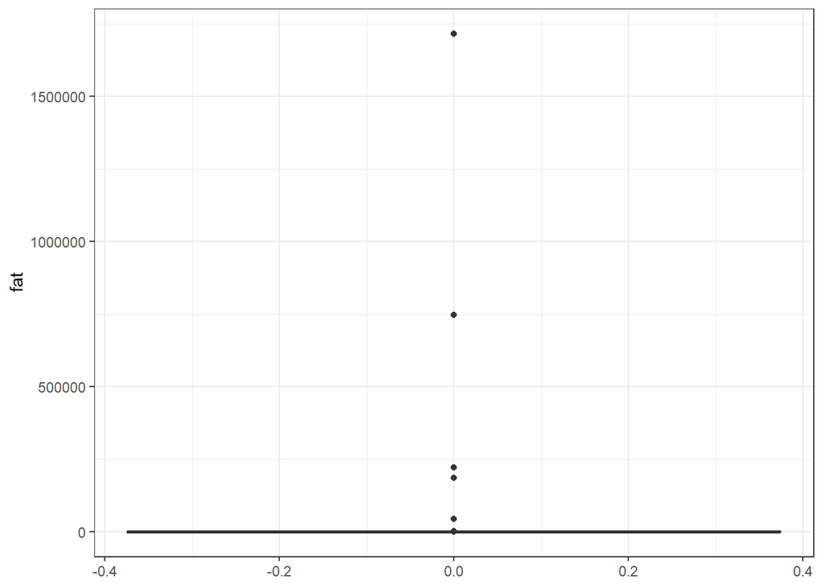

```r
recipes[-id_error[1], ] %>% ggplot(aes(y = fat)) + geom_boxplot() + theme_bw()
```

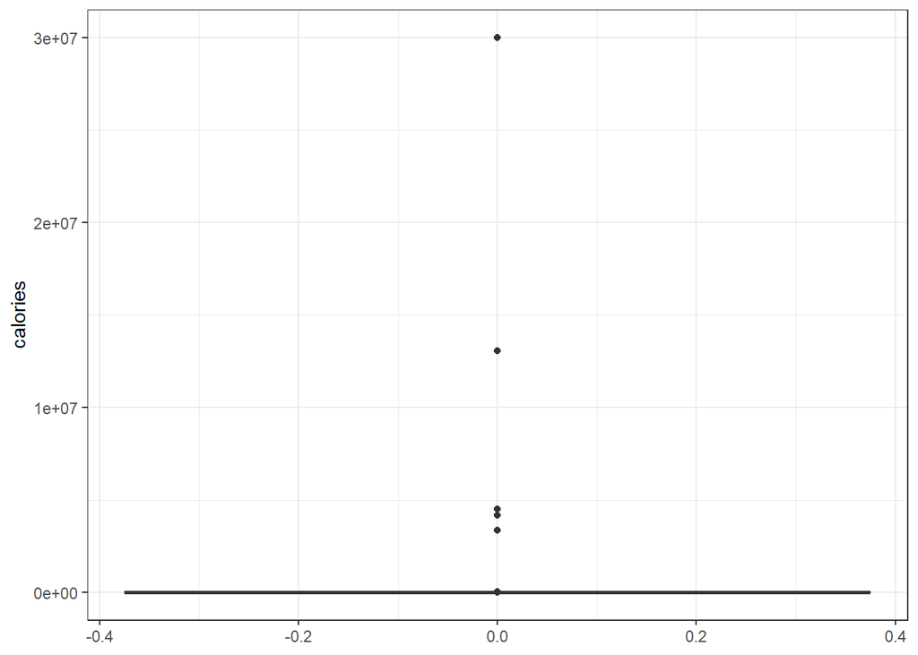

```r
recipes[-id_error[2], ] %>% ggplot(aes(y = calories)) + geom_boxplot() + theme_bw()
```

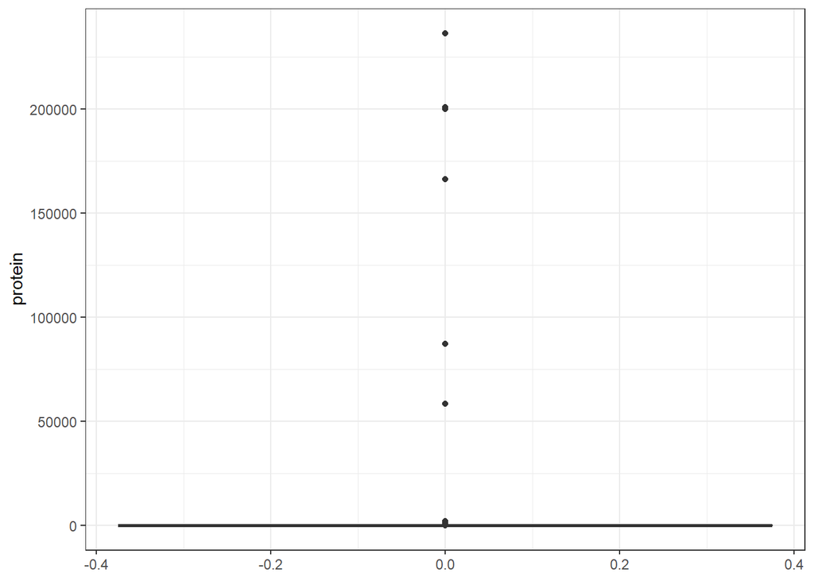

```r
recipes[-id_error[3], ] %>% ggplot(aes(y = protein)) + geom_boxplot() + theme_bw()
```

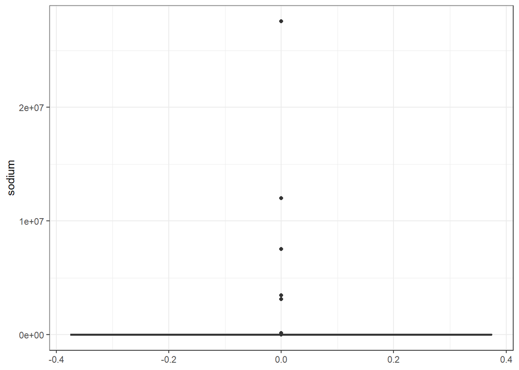

```r
recipes[-id_error[4], ] %>% ggplot(aes(y = sodium)) + geom_boxplot() + theme_bw()
```

## Imputação de dados

Em outras palavras, receitas que ultrapassem os limiares citados acima, nas suas respectivas variáveis, serão substituídas pela média truncada em 5%. O número de receitas que ultrapassam estes limiares são 678, 234, 441 e 328 para `fat`, `calories`, `protein` e `sodium`, respectivamente.

```r
c(sum(na.omit(recipes$fat) >= 93), sum(na.omit(recipes$calories) >= 2500),
  sum(na.omit(recipes$protein) >= 100), sum(na.omit(recipes$sodium) >= 3400))
```

```
## [1] 678 234 441 328
```

```r
id_error_fat <- which(recipes$fat >= 93)
id_error_calories <- which(recipes$calories >= 2500)
id_error_protein <- which(recipes$protein >= 100)
id_error_sodium <- which(recipes$sodium >= 3400)
```

```r
fat_trim_mean <- mean(recipes$fat, na.rm = TRUE, trim = .05)
calories_trim_mean <- mean(recipes$calories, na.rm = TRUE, trim = .05)
protein_trim_mean <- mean(recipes$protein, na.rm = TRUE, trim = .05)
sodium_trim_mean <- mean(recipes$sodium, na.rm = TRUE, trim = .05)

fat <- ifelse(is.na(recipes$fat), fat_trim_mean, recipes$fat)
calories <- ifelse(is.na(recipes$calories), fat_trim_mean, recipes$calories)
protein <- ifelse(is.na(recipes$protein), fat_trim_mean, recipes$protein)
sodium <- ifelse(is.na(recipes$sodium), fat_trim_mean, recipes$sodium)

fat[id_error_fat] <- fat_trim_mean
calories[id_error_calories] <- calories_trim_mean
protein[id_error_protein] <- protein_trim_mean
sodium[id_error_sodium] <- sodium_trim_mean
```

## Criação de novas features

Acreditamos que a nota da receita está relacionada a dificuldade da mesma, pois receitas muito difíceis podem não ser concluídas com sucesso e com isso ter sua nota diminuída e vice versa. Então, elencamos algumas medidas para avaliar a dificuldade da receita, são elas: (1) número de processos (`num_process`); (2) cozida, assada, ou vai ao forno (`baked`); (3) número de caracteres (concisão) (`conciseness`); (4) preparation time (`time`).

```r
num_process <- sapply(recipes[[1]], function(x) length(x))
baked <- str_detect(recipes$directions, '°F|°C|°K')
conciseness <- str_length(recipes$directions)

hour <- sapply(str_extract_all(recipes$directions, "\\d+(?=\\shour)"),
               function(x) sum(as.numeric(x)))
minutes <- sapply(str_extract_all(recipes$directions, "\\d+(?=\\sminute)"),
               function(x) sum(as.numeric(x)))
time <- 24 * hour + minutes
```

Número de dias desde a publicação da receita pode ser um fator decisivo na nota da receita. Além disso, criamos uma variável que determina se uma “receita é clássica” ou não, elas são consideradas clássicas se tem mais de 10 anos (3650 dias) desde a publicação. Através de uma variável dummy `old_recipe` sabemos se as receitas são clássicas ou não.

```r
date <- recipes %>% mutate(date, date1 = as.Date(date)) %>% select(date1)
num_days <- as.numeric(Sys.Date() - date$date1)
num_days[which(is.na(num_days))] <- mean(num_days, na.rm = TRUE)
old_recipe <- (num_days >= 3650) %>% as.integer() %>% as.factor()
```

Outra importante variável para a nota da receita são as categorias que ela está inserida. Nós calculamos e armazenamos o número de categorias em que uma receita está inserida (`num_categories`) e verificamos também se está é vegetariana ou não (`vegetarian`). Além disso, verificamos quais as categorias são mais frequentes nas receitas através da variável `freq_cat`

```r
num_categories <- sapply(recipes$categories,
                         function(x) length(x))

vegetarian <- recipes %>%
  select(categories) %>%
  sapply(function(x) str_detect(x, pattern = 'Vegetarian')) %>%
  as.integer() %>% as.factor()

cat <- sapply(recipes$categories,
              function(x) stringi::stri_trans_general(x, "Latin-ASCII")  )

freq_cat <- factor(unlist(recipes$categories),
                         levels = unique(unlist(recipes$categories)))
summary(freq_cat) %>% head(10)
```

```
##       Bon Appétit       Peanut Free          Soy Free     Tree Nut Free
##              9355              8390              8088              7044
##        Vegetarian           Gourmet            Kosher       Pescatarian
##              6846              6648              6175              6042
##      Quick & Easy Wheat/Gluten-Free
##              5372              4906
```

A descrição da receita funciona como um subtítulo da receita e pode ser um fator de engajamento a executar a receita. Dessa forma, pode ter influência sobre a avaliação da receita. Portanto, três variáveis foram criadas, a primeira verifica se há descrição na receita, a segunda indica o número de orações de sentido completo na descrição e a terceira revela o número de caracteres na descrição. Elas são descritas pelas variáveis `desc`, `phrases` e `desc_len`, respectivamente.

```r
desc <- recipes %>% select(desc) %>% is.na() %>% as.numeric()

phrases <- recipes %>%
  select(desc) %>%
  apply(1,
        function(x) str_count(x, pattern = '\\.|\\:|\\?|\\!|\\;'))
phrases <- ifelse(is.na(phrases), 0, phrases)

desc_len <- recipes %>% select(desc) %>% apply(1,
                                                function(x) str_length(x))
desc_len <- ifelse(is.na(desc_len), 0, desc_len)
```

Estudando a variável ingredientes podemos detectar que algumas receitas não apresentam nenhum ingrediente assim, não foram consideradas receitas válidas e foram deletadas do banco de dados. Para execução do processo de deleção utilizamos a variável `rwi` que significa “recipes wihtout ingredients”. A base de dados `recipes2` armazena a nova base de dados sem as receitas inválidas. Em seguida, contamos o número de ingredientes por receita.

```r
rwi <- which(sapply(recipes$ingredients, length) == 0)
rwi
```

```
##  [1]   774  1077  1080  1136  1454  1641  1908  2067  2692  2726  3331
## [12]  4507  4508  5147  5163  5425  5559  5817  6330  6700  6879  7026
## [23]  7585  7608  7769  7803  7882  8178  8335  9591  9663  9924 10086
## [34] 10207 10239 10601 10946 11176 11225 11632 11699 12056 12698 12790
## [45] 13152 13207 13243 13245 13303 13348 13382 13468 13555 13711 13945
## [56] 14260 14685 15325 15977 16046 16211 16331 16836 16904 16947 17331
## [67] 17619 18109 18262 18678 18744 18768 19128 19525 19548 19643
```

```r
recipes2 <- recipes[-rwi, ]

num_ingredients <- recipes2$ingredients %>% sapply(function(x) length(x))
```

```r
recipes2 %>%
  select(rating) %>%
  summary()
```

```
##      rating
##  Min.   :0.000
##  1st Qu.:3.750
##  Median :4.375
##  Mean   :3.715
##  3rd Qu.:4.375
##  Max.   :5.000
##  NA's   :11
```

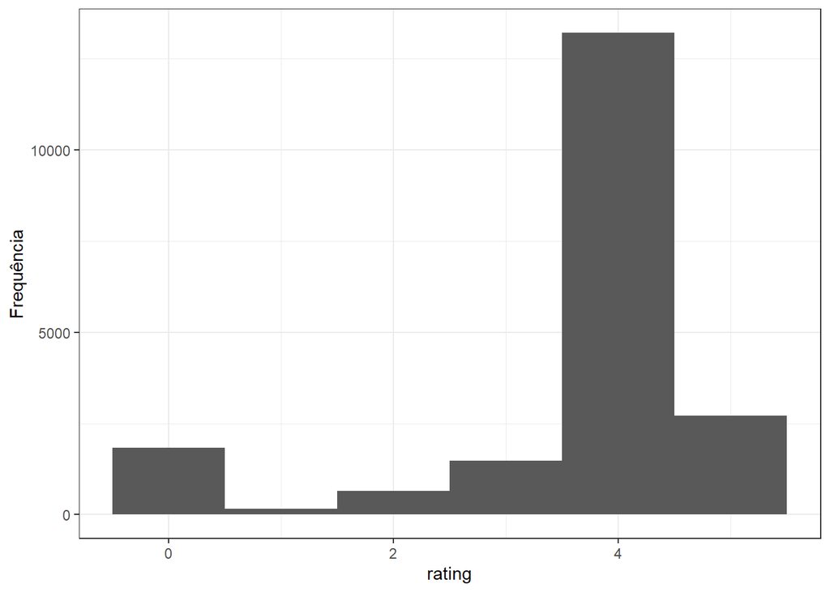

```r
recipes2 <- recipes2 %>% mutate(rating, rating = ifelse(is.na(rating),
                                             mean(rating, na.rm = TRUE), rating))

recipes2 %>%
  ggplot(aes(rating)) + geom_histogram(bins = 6) + ylab('Frequency') +
  ylab('Frequência') + theme_bw()
```

Através das variáveis originais e das criadas neste estudo (features) montamos um novo dataset denominado de `recipes3`. Com este novo dataset estudamos quais variáveis podem influenciar na nota de uma receita.

```r
recipes3 <- data.table(recipes2$title, recipes2$rating, fat[-rwi], calories[-rwi],
                       protein[-rwi], sodium[-rwi], num_categories[-rwi],num_days[-rwi],
                       num_ingredients, num_process[-rwi], baked[-rwi],
                       conciseness[-rwi], desc[-rwi], desc_len[-rwi], old_recipe[-rwi],
                       phrases[-rwi], time[-rwi], vegetarian[-rwi],
                       recipes2$categories, recipes2$ingredients)

names(recipes3) <- c('title', 'rating', 'fat', 'calories', 'protein', 'sodium',
                     'num_categories', 'num_days', 'num_ingredients', 'num_process',
                     'baked', 'conciseness', 'desc', 'desc_len', 'old_recipe', 'phrases',
                     'time', 'vegetarian', 'categories', 'ingredients')

recipes3$desc <- recipes3$desc %>%
  as.integer() %>%
  as.factor()

recipes3$baked <- recipes3$baked %>%
  as.integer() %>%
  as.factor()
```

As 10 receitas com maior teor calórico são descritas abaixo.

```r
caloric_recipes <- recipes3 %>%
  arrange(desc(calories)) %>% slice(1 : 10)
caloric_recipes
```

| title | rating | fat | calories | protein | sodium | num_categories | num_days | num_ingredients | num_process | baked | conciseness | desc | desc_len | old_recipe | phrases | time | vegetarian | categories | ingredients |
| --- | --- | --- | --- | --- | --- | --- | --- | --- | --- | --- | --- | --- | --- | --- | --- | --- | --- | --- | --- |
| Strawberry-Blueberry Napoleons | 5.00 | 76.00000 | 2493 | 52.00000 | 444.0048 | 19 | 5598 | 10 | 6 | 1 | 2461 | 1 | 0 | 1 | 0 | 128 | 1 |  |  |
| Southern-Style Fried Chicken | 0.00 | 76.00000 | 2484 | 15.80889 | 1791.0000 | 13 | 2540 | 8 | 2 | 1 | 907 | 1 | 0 | 0 | 0 | 30 | 0 |  |  |
| Southern-Style Fried Chicken | 0.00 | 76.00000 | 2484 | 15.80889 | 1791.0000 | 13 | 2540 | 8 | 2 | 1 | 907 | 1 | 0 | 0 | 0 | 30 | 0 |  |  |
| Gaga Filling | 0.00 | 22.17656 | 2478 | 15.80889 | 444.0048 | 16 | 4902 | 8 | 4 | 1 | 885 | 0 | 50 | 1 | 1 | 30 | 1 |  |  |
| Trenton Tomato Pie Pizza | 5.00 | 22.17656 | 2477 | 15.80889 | 444.0048 | 6 | 1224 | 8 | 6 | 1 | 944 | 0 | 160 | 0 | 1 | 43 | 0 |  |  |
| Squash Blossoms Stuffed With Ricotta | 5.00 | 22.17656 | 2477 | 32.00000 | 425.0000 | 15 | 3772 | 15 | 5 | 1 | 995 | 0 | 434 | 1 | 4 | 32 | 1 |  |  |
| Crown Roast of Lamb with Shallots, Mustard and Mint | 5.00 | 22.17656 | 2476 | 27.00000 | 177.0000 | 9 | 5598 | 14 | 5 | 1 | 1355 | 1 | 0 | 1 | 0 | 106 | 0 |  |  |
| Winter Fruit and Nut Stuffing | 5.00 | 44.00000 | 2473 | 88.00000 | 444.0048 | 17 | 5598 | 14 | 4 | 1 | 1241 | 0 | 184 | 1 | 1 | 110 | 1 |  |  |
| Sauteed Pork Chops with Sweet-and-Sour Red Cabbage | 3.75 | 22.17656 | 2466 | 15.80889 | 1759.0000 | 15 | 4867 | 12 | 5 | 1 | 1574 | 0 | 111 | 1 | 1 | 55 | 0 |  |  |
| Nutty Monk | 0.00 | 18.00000 | 2457 | 4.00000 | 22.0000 | 14 | 3975 | 7 | 3 | 1 | 855 | 0 | 152 | 1 | 1 | 1162 | 0 |  |  |

Considerando as 10 receitas com maior teor calórico verificamos as principais categorias que estas receitas pertencem, respectivamente, são: (1) Peanut Free; (2) Soy Free; (3) Tree Nut Free; (4) Dinner; (5) Vegetarian; (6) Pescatarian; (7) Kosher; (8) Bon Appétit; (9) Party; (10) Sugar Conscious.

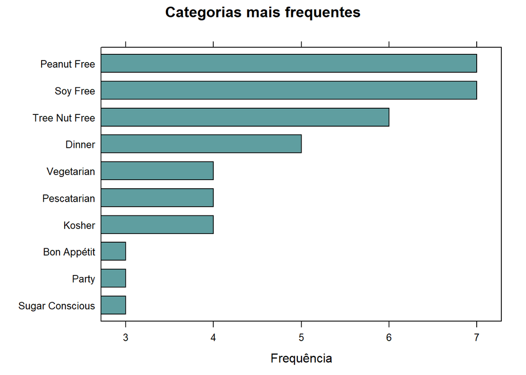

```r
stats <- txt_freq(unlist(caloric_recipes$categories))
library(lattice)
stats$key <- factor(stats$key, levels = rev(stats$key))
barchart(key ~ freq, data = head(stats, 10),
         col = "cadetblue", main = "Categorias mais frequentes", xlab = "Frequência")
```

```r
stats %>% slice(1 : 10)
```

| key | freq | freq_pct |
| --- | --- | --- |
| Peanut Free | 7 | 5.109489 |
| Soy Free | 7 | 5.109489 |
| Tree Nut Free | 6 | 4.379562 |
| Dinner | 5 | 3.649635 |
| Vegetarian | 4 | 2.919708 |
| Pescatarian | 4 | 2.919708 |
| Kosher | 4 | 2.919708 |
| Bon Appétit | 3 | 2.189781 |
| Party | 3 | 2.189781 |
| Sugar Conscious | 3 | 2.189781 |

Considerando as 10 receitas com maior teor calórico podemos observar através do gráfico abaixo que o ingrediente mais presente nelas é `chicken` seguido de `pepper`, `butter`, `sugar`, `salt` e outros.

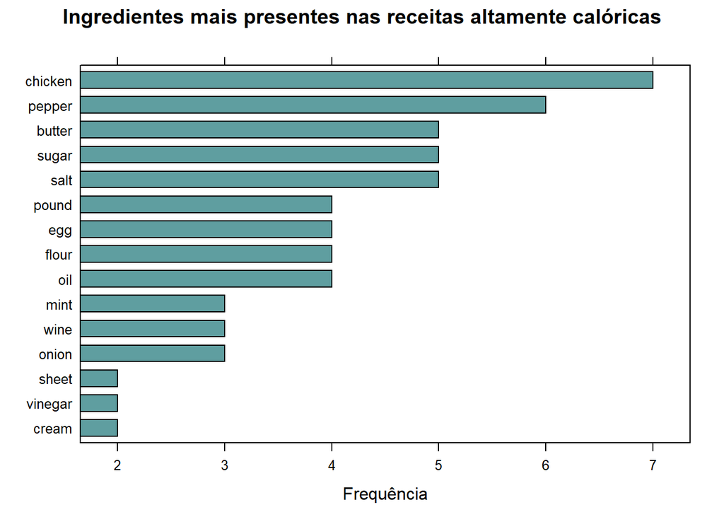

```r
drop_words <- c('cup', 'cups', 'teaspoon', 'teaspoons', 'tablespoons', 'tablespoon',
                'peel', 'pound', 'ground', 'preserve', 'inch', 'piece', 'stick', 'slice',
                'large', 'optional', 'ounce', 'leave', 'purpose', 'powder', 'broth',
                'baking', 'ounces', 'pieces', 'cube')


ingredients <- caloric_recipes$ingredients %>%
  lapply(function(x) removeWords(x, drop_words)) %>%
  lapply(function(x) removeWords(x, stopwords('english'))) %>%
  lapply(function(x) str_replace_all(x, '[^[:alnum:]]', ' ')) %>%
  lapply(function(x) removeNumbers(x)) %>%
  lapply(function(x) stripWhitespace(x))


if(file.exists('english-ewt-ud-2.4-190531.udpipe')){
  ud_model <- udpipe_load_model('english-ewt-ud-2.4-190531.udpipe')
}else{
  ud_model_temp <- udpipe_download_model(language = "english")
  ud_model <- udpipe_load_model(ud_model_temp$file_model)
}

x <- udpipe_annotate(ud_model, x = unlist(ingredients))
x <- as.data.frame(x)

stats <- subset(x, upos %in% "NOUN")
stats <- txt_freq(x = stats$lemma)

stats$key <- factor(stats$key, levels = rev(stats$key))
barchart(key ~ freq, data = head(stats, 15),
         col = "cadetblue", main = "Ingredientes mais presentes nas receitas altamente calóricas", xlab = "Frequência")
```

```r
recipes3[with(recipes3, order(-rating, fat, calories, sodium,
                              num_process, conciseness)), ] %>%
  slice(1 : 3)
```

| title | rating | fat | calories | protein | sodium | num_categories | num_days | num_ingredients | num_process | baked | conciseness | desc | desc_len | old_recipe | phrases | time | vegetarian | categories | ingredients |
| --- | --- | --- | --- | --- | --- | --- | --- | --- | --- | --- | --- | --- | --- | --- | --- | --- | --- | --- | --- |
| To Clarify Butter | 5 | 0 | 0 | 0 | 0 | 3 | 5598 | 1 | 1 | 0 | 232 | 1 | 0 | 1 | 0 | 3 | 0 |  |  |
| To Clarify Butter | 5 | 0 | 0 | 0 | 0 | 3 | 5598 | 1 | 1 | 0 | 232 | 1 | 0 | 1 | 0 | 3 | 0 |  |  |
| Dashi (Japanese Sea Stock) | 5 | 0 | 0 | 0 | 26 | 3 | 5598 | 3 | 1 | 0 | 406 | 0 | 77 | 1 | 1 | 3 | 0 |  |  |

# Modelagem

Com objetivo de identificar se há algum fator determinante para a alta nota de uma receita transformamos a nota numa variável dummy, em que receitas com notas iguais ou maiores que 4.0 são consideradas receitas bem avaliadas, caso contrário não. Em seguida, extraímos as regras mais importantes de uma árvore de decisão que fazem uma receita ser ou não bem avaliada.

```r
recipes4 <- recipes3 %>% dplyr::select(-one_of('categories', 'ingredients', 'title')) %>%
  mutate(rating, rating = ifelse(rating >= 4.0, 1, 0) %>% as.factor())


fit_tree <- rpart(formula = rating ~., data = recipes4)
asRules(fit_tree)
```

```
##
##  Rule number: 3 [rating=1 cover=11474 (57%) prob=0.59]
##    num_ingredients>=8.5
##
##  Rule number: 23 [rating=1 cover=3418 (17%) prob=0.55]
##    num_ingredients< 8.5
##    time>=8.5
##    num_days>=1726
##    calories>=125.5
##
##  Rule number: 22 [rating=0 cover=1776 (9%) prob=0.46]
##    num_ingredients< 8.5
##    time>=8.5
##    num_days>=1726
##    calories< 125.5
##
##  Rule number: 4 [rating=0 cover=3127 (16%) prob=0.39]
##    num_ingredients< 8.5
##    time< 8.5
##
##  Rule number: 10 [rating=0 cover=259 (1%) prob=0.27]
##    num_ingredients< 8.5
##    time>=8.5
##    num_days< 1726
```

Neste ponto, selecionamoas as cem melhores receitas segundo a nota de avaliação para o estudo das categorias que possuem mais receitas.

```r
recipes_top100 <- recipes3 %>%
  arrange(desc(rating)) %>%
  slice(1 : 100)
```

Com a função abaixo fizemos um crawler com objetivo de verificar quais das 100 primeiras receitas estão no site [epicurious](https://www.epicurious.com). A função `epicurious` recebe o nome das receitas (`title`) e retorna o link da receitas no site, caso ela se encontre nele, é retornado também uma variável booleana que indica se a variável foi encontrada na busca do site ou não.

```r
title_top100 <- recipes_top100 %>% dplyr::select(title)

urls <- rbindlist(lapply(title_top100, function(x){
  url <- paste('https://www.epicurious.com/search/', x, sep = '')
  tibble(url)
}), fill = TRUE)


epicurious <- function(recipe_title){
  recipe_title <- recipe_title %>% stringi::stri_trans_general('Latin-ASCII')
  recipe_title <- recipe_title %>% str_replace('\'s', '')

  names_recipes <- paste(paste('recipe', seq_along(recipe_title),
                               sep = ''), '.xml', sep = '')
  out <- rep(0, length(recipe_title))

  for(i in seq_along(recipe_title)){
    recipe_url <- recipe_title[i] %>%
      as.character()

    recipe_url <- paste('https://www.epicurious.com/search/', recipe_url, sep = '')

    if(!(file.exists(names_recipes[i]))){
      download.file(recipe_url, destfile = names_recipes[i])
    }

    recipes_xml <- read_html(names_recipes[i]) %>%
      htmlParse()

      links <- getHTMLLinks(recipes_xml, externalOnly = TRUE,
                               xpQuery = "//a/@href", baseURL = docName(recipes_xml),
                               relative = FALSE)
      url_recipe <- links[links %>% str_detect('/recipes/food/views/')][1]
      out[i] <- paste('https://www.epicurious.com', url_recipe, sep = '')

      first_word_recipe_title <- recipe_title[i] %>%
        str_replace('-', ' ') %>%
        str_replace('[:punct:]', '') %>%
        str_to_lower() %>%
        removeWords(stopwords('english')) %>%
        str_replace_all('[^[:alnum:]]', ' ') %>%
        removeNumbers() %>%
        stripWhitespace() %>%
        word()

      out[i] <- ifelse(out[i] %>%
                         str_detect(first_word_recipe_title), out[i], 0)
  }
  list('link' = out,
       'inside_epicurious' = ifelse(out != 0, TRUE, FALSE) )
}
```

A seguir, vemos as trinta categorias que possuem mais receitas.

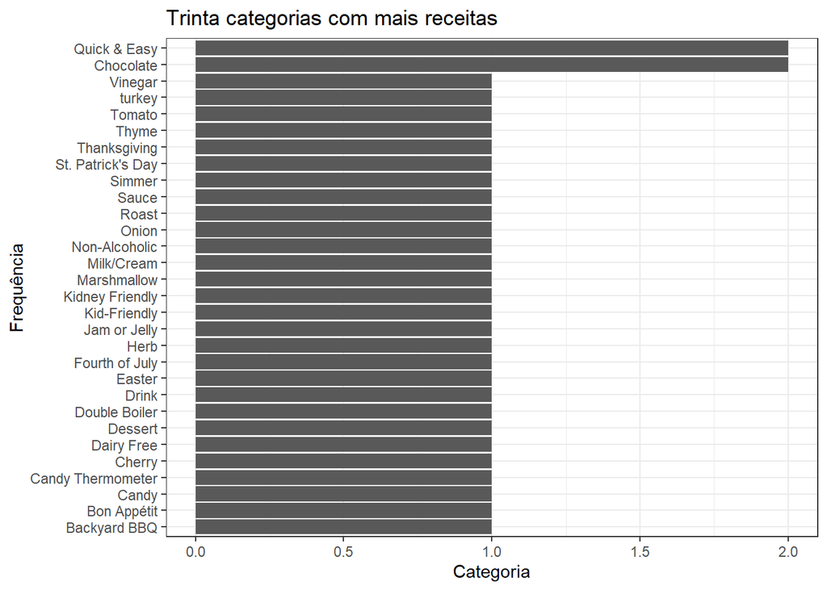

```r
cat_existents <- unique(unlist(recipes_top100[recipes_in_epicurious$inside_epicurious,                                                                                     ]$categories))
num_recipes_cat <- lapply(recipes_top100[recipes_in_epicurious$inside_epicurious,
                                                 ]$categories,
                                  function(x) factor(x, cat_existents))

num_recipes_cat <- lapply(num_recipes_cat, function(x) dummy_cols(x))
num_recipes_cat <- lapply(num_recipes_cat, function(x) data.matrix(x,
                                                                   rownames.force = NA))

num_recipes_cat <- t(sapply(num_recipes_cat, function(y) apply(y, 2, sum)))
num_recipes_cat <- apply(num_recipes_cat, 2,  function(x) sum(x))[-1]

recipes_by_cat <- data.frame(categorie = as.factor(cat_existents),
                          num_recipes_cat = num_recipes_cat) %>%
  arrange(desc(num_recipes_cat))

g <- recipes_by_cat[1:30, ] %>% ggplot(aes(x = reorder(categorie, num_recipes_cat), y = num_recipes_cat)) +
  geom_bar(stat = 'identity') +  coord_flip() + theme_bw() +
  xlab('Frequência') + ylab('Categoria') + ggtitle('Trinta categorias com mais receitas')
g
```

# Considerações, limitações da solução e feedback

O presente desafio deu oportunidade de mostrar conhecimento em áreas diversas de ciência de dados, desde a limpeza de dados, passando pela necessidade de conhecimento de especialistas até a identificação de fatores que influenciam uma variável resposta.

Esta solução não é definitiva podendo assim, ser aprimorada em tempo oportuno. Portanto, há algumas limitações que podem ser melhoradas em etapas futuras, tais como:

- Definição do limiar para detecção de erro de medição - esta etapa pode ser facilmente refinada quando se há conhecimento melhorado do domínio, disponibilidade de consulta a especialista (cliente); ou ainda através de investigação de modelos estatísticos avançados não usuais na literatura de ciência de dados;
- O crawler que verifica a existência de uma receita no site epicurious é um protótipo, podendo ser melhorado;
- A sexta questão pode ser resolvia através de sistemas de recomendação, por exemplo, cgontent-based filtering. Porém há limitações técnicas e teóricas, temporárias, que impossibilitam a solução do problema no tempo estabelecido;
- Feedback - A variável `rating` de modo purista deve ser analisado por um modelo estatístico cuja distribuição de probabilidade tenha suporte no intervalo [0, 5], ou seja, modelos dessa natureza garantem matematicamente que as predições e previsões não estaram fora do domínio da variável. Portanto, a detecção de fatores importantes que influenciam na nota de uma receita pode ser feita através de modelos desta natureza. Contudo, a carga teórica para apredizagem de modelos deste tipo pode durar de uma semana a um mês. Uma possível solução para isto é perder um pouco de informação binarizando (tornando dummy) a variável em estudo com isso, podemos aplicar um modelo de regressão logística ou árvore de decisão para extração de regras. Sendo o último a abordagem utilizada.

Por fim, abaixo temos o tempo para solução de todas as questões obrigatórias.

```r
Sys.time() - start
```

```
## Time difference of 1.452177 mins
```